# Impact of Non-Cognitive Interventions on Student Learning Behaviors and Outcomes: An analysis of seven large-scale experimental inventions

## Paper Details:

- Acm Conference LAK23: 13th International Learning Analytics and Knowledge Conference (LAK 2023), March 13–17, 2023, Arlington, TX, USA
- DOI: 10.1145/3576050.3576073
- ACM ISBN: 978-1-4503-9865-7/23/03
- https://dl.acm.org/doi/abs/10.1145/3576050.3576073

**Authors**

- Vanacore,Kirk
- Gurung, Ashsish
- McReynolds, Andrew A.
- Lui, Alison
- Shaw, Stacy T.
- Heffernan, Neil T.

## Abstract

As evidence grows supporting the importance of non-cognitive factors in learning, computer-assisted learning platforms increasingly incorporate non-academic interventions to influence student learning and learning related-behaviors. Non-cognitive interventions often attempt to influence students’ mindset, motivation, or metacognitive reflection to impact learning behaviors and outcomes. In the current paper, we analyze data from five experiments, involving seven treatment conditions embedded in mastery-based learning activities hosted on a computer-assisted learning platform focused on middle school mathematics. Each treatment condition embodied a specific non-cognitive theoretical perspective. Over seven school years, 20,472 students participated in the experiments. We estimated the effects of each treatment condition on students’ response time, hint usage, likelihood of mastering knowledge components, learning efficiency, and post-tests performance. Our analyses reveal a mix of both positive and negative treatment effects on student learning behaviors and performance. Few interventions impacted learning as assessed by the post-tests. These findings highlight the difficulty in positively influencing student learning behaviors and outcomes using non-cognitive interventions.

### Research Questions

As we are interested in understanding whether non-cognitive interventions affect learning-related behaviors as well as learning measures as outcomes, our research questions focus on a variety of different variables as outcomes:

#### RQ1: Did each intervention increase students’ initial response time when solving a problem?

As response time (defined as the time between viewing the problem and either submitting a response or requesting a hint) is positively correlated with performance , we analyzed whether each intervention impacted the amount of time between viewing the problem and taking an action (response time) as a learning-related outcome. This allows us to evaluate whether the interventions cause students to slow down and consider the problem prior to acting, an action that is related to learning and performance .

#### RQ2: Did each intervention increase the likelihood of students engaging in hint usage during the activity?}

Providing access to hints has a positive effect on student performance , so the likelihood that students utilized hints as a help-seeking behavior was included as an outcome. This allows us to measure the extent to which the interventions cause students to seek assistance as they worked through the activity.

#### RQ3: Did each intervention increase the likelihood that students completed the activity by mastering the knowledge component?

The goal of each activity in ASSISTments is to master the knowledge components, so we evaluate each intervention’s impact on the likelihood that the students reach this goal. Notably, mastery can be viewed as a product of student knowledge entering the activity, learning during the activity, and their willingness to persist through the activity.

#### RQ4: Did each intervention impact student learning as measured by their efficiency in mastering the knowledge component of the activity and performance on a post-test?

Students required different numbers of problems before reaching mastery and may have experienced different levels of learning during the activity. Therefore, we examined whether the interventions impacted the efficiency in which students learned by examining the difference in the number of problems to mastery, and we evaluated how much learning they experienced during the activity by assessing differences in their performance on a post-test.

```r
# prepare libraries
packages = c(
  "tidyverse",
  "plyr",
  "ggExtra",
  "xts",
  "lubridate",
  "readxl",
  "ggpubr",
  "data.table",
  "RSQLite",
  "DBI",
  "mice"
  ,"psych",
  "stringr",
  "sjmisc",
  "lme4",
  "campfin",
  "pROC",
  "cutpointr",
  "missForest",
  "corrplot",
  "tidyverse",
  "arm",
  "lubridate",
  "xtable",
  "psych"
)
#load install
package.check <- lapply(
  packages,
  FUN = function(x) {
    if (!require(x, character.only = TRUE)) {
      install.packages(x, dependencies = TRUE)
      library(x, character.only = TRUE)
    }
  }
)
rm(package.check, packages)
options(max.print=1000000)
options(scipen = 100)
gc()
```

```
##           used  (Mb) gc trigger  (Mb) limit (Mb) max used  (Mb)
## Ncells 2757080 147.3    4402781 235.2         NA  4402781 235.2
## Vcells 4601890  35.2   10146329  77.5      16384  8133455  62.1
```

```r
v1 <- read_csv("/Users/kirkvanacore/Documents/WPI_Analyses/Non-Cognitive-Interventions_ASSSITments/02_data/motivational_v1.csv") %>%
  mutate(
    v = 1,
    user_id = paste0("v1", user_id),
    assignment_id  = paste0("v1", assignment_id),
    problem_log_id  = paste0("v1", problem_log_id),
    teacher_id  = paste0("v1", teacher_id),
    student_class_id  = paste0("v1", student_class_id)
  )
v1_new <- read_csv("/Users/kirkvanacore/Documents/WPI_Analyses/Non-Cognitive-Interventions_ASSSITments/02_data/motivational_v1_new.csv") %>%
  mutate(
    v = 1,
    user_id = paste0("v1", user_id),
    assignment_id  = paste0("v1", assignment_id),
    problem_log_id  = paste0("v1", problem_log_id),
    teacher_id  = paste0("v1", teacher_id),
    student_class_id  = paste0("v1", student_class_id)
  )
v2 <- read_csv("/Users/kirkvanacore/Documents/WPI_Analyses/Non-Cognitive-Interventions_ASSSITments/02_data/motivational_v2.csv")%>%
  mutate(
    v = 2,
    user_id = paste0("v2", user_id),
    assignment_id  = paste0("v2", assignment_id),
    problem_log_id  = paste0("v2", problem_log_id),
    teacher_id  = paste0("v2", teacher_id),
    student_class_id  = paste0("v2", student_class_id)
  )
v2_new <- read_csv("/Users/kirkvanacore/Documents/WPI_Analyses/Non-Cognitive-Interventions_ASSSITments/02_data/motivational_v2_new.csv")%>%
  mutate(
    v = 2,
    user_id = paste0("v2", user_id),
    assignment_id  = paste0("v2", assignment_id),
    problem_log_id  = paste0("v2", problem_log_id),
    teacher_id  = paste0("v2", teacher_id),
    student_class_id  = paste0("v2", student_class_id)
  )
merge <- rbind(v1, v1_new, v2, v2_new)
rm(v1, v1_new, v2, v2_new)
#str(dat)
```

## Data

```r
experiments <- data.frame(
  psa_id = c(
    "PSA2KNM",
    "PSA2KNP",
    "PSA59TQ",
    "PSA7GUA",
    "PSA9XWV",
    "PSA2KQB",
    "PSAV89B",
    "PSAWU6Z"
  ),
  experiment = c(
    "Embracing Mistakes",
    "Embracing Mistakes",
    "Inspirational Quotes",
    "Inspirational Quotes",
    "Social Comparison",
    "Emotion Labeling",
    "Confidence Judgments",
    "Confidence Judgments"
  ),
  num_posttest_problems = c(2, 2, 3, 2, 3, 2, 0, 0)

)


dat <- merge %>%
  left_join(
    experiments,
    by = "psa_id"
  ) %>%
  dplyr::ungroup() %>%
    dplyr::filter(

    !control_treatments  %in% c("ignore_posttest",
                                "ignore_guide_problems",
                                "unassigned", # never randomized
                                "competency_check_problem"
                             #,   "treatment2:plain_message" # dropping active control for confideince experiment
                                ),
    !(control_treatments  %in% c("control") &  psa_id %in% c("PSAV89B", "PSAWU6Z")) # droping BAU control for confedince judgment experments
    ) %>%
  dplyr::mutate(

    control_treatments2 = ifelse(control_treatments == "treatment2:plain_message",
                                "control", control_treatments),

        posttest = ifelse(control_treatments == "posttest", 1, 0),
        sb_problem = ifelse(!grepl("ignore", section_names) & posttest != 1, 1, 0),
        correct = ifelse(continuous_score == 1, 1, 0),
                control = ifelse(startsWith(control_treatments, "control") == T | endsWith(control_treatments, "plain_message"), 1, 0),
        treatment = ifelse(startsWith(control_treatments, "treatment") & !endsWith(control_treatments, "plain_message") == T, 1, 0),
        video_fail = ifelse(control_treatments == "video_check_fail", 1, 0)

  ) %>%
  dplyr::group_by(user_id, psa_id, assignment_id) %>%
  mutate(
    treatment = ifelse(sum(treatment) > 0, 1, 0),
    control = ifelse(sum(control) > 0, 1, 0),
    video_fail = ifelse(sum(video_fail) > 0, 1, 0),
    never_randomized = ifelse(treatment == 0 & control == 0, 1, 0),
    posttest_responses = sum(posttest)
  ) %>%
  filter(
    # these are students who were never randomized
    video_fail == 0,
    (never_randomized == 0)

  ) %>%
  ### drop second + exposures to the same experiment
  ungroup() %>%
   group_by(user_id, psa_id) %>%
    arrange(assignment_id ) %>%
  dplyr::mutate(running_exp_count = match(assignment_id, unique(assignment_id))) %>%
  filter(
    # keep only first exposure to the experiment
    running_exp_count == 1 ,
    posttest_responses <= num_posttest_problems
  ) %>%
  group_by(user_id, psa_id) %>%
  ### label conditions
  mutate(
    conditon = ifelse(control == 1, "control",
                          ifelse(sum(ifelse(endsWith(control_treatments, "text"), 1,0)) >0, "Embracing Mistakes (Image)",
                                 ifelse(sum(ifelse(endsWith(control_treatments, "video"), 1,0)) >0, "Embracing Mistakes (Video)",
                                        ifelse(sum(ifelse(endsWith(control_treatments, "encouragement"), 1,0)) >0, "Inspirational Quotes",
                                               ifelse(sum(ifelse(endsWith(control_treatments, "10_to_mastery"), 1,0)) >0, "Social Comparison (Performance)",
                                                      ifelse(sum(ifelse(endsWith(control_treatments, "high_hint_usage"), 1,0)) >0, "Social Comparison (Help Seeking)",
                                                             ifelse(sum(ifelse(endsWith(control_treatments, "competency_check"), 1,0)) >0, "Confidence Judgments",
                                                                    ifelse(sum(ifelse(endsWith(control_treatments, "same_diff_in_correctness"), 1,0)) >0,
                                                                           "Emotion Labeling",
                                                                           NA)))))))),
    treatment1 = ifelse(treatment == 1 & conditon != "Embracing Mistakes (Image)" &  conditon != "Social Comparison (Help Seeking)",
                        1, 0),
    treatment2 = ifelse(conditon == "Embracing Mistakes (Image)" | conditon == "Social Comparison (Help Seeking)",
                        1, 0))
```

#### Dates

```r
paste("Years:")
```

```
## [1] "Years:"
```

```r
table(year(lubridate::as_date(dat$problem_log_end_time)))
```

```
##
##  2015  2016  2017  2018  2019  2020  2021  2022
##  2609 15122 31691 35049 23710 37323 34739  9578
```

```r
( paste("Min Date:", min(dat$problem_log_end_time)))
```

```
## [1] "Min Date: 2015-10-26 09:15:35"
```

```r
( paste("Max Date:", max(dat$problem_log_end_time)))
```

```
## [1] "Max Date: 2022-09-20 01:02:45"
```

### Sample

```r
stud_ex <- dat %>%
  ungroup() %>%
  dplyr::group_by(user_id, psa_id, assignment_id) %>%
  dplyr::mutate(
    num_expose = length(unique(paste(
      user_id, psa_id, assignment_id
    ))),
    num_hints = sum(hint_count),
    avg_first_response_time = mean(ifelse(sb_problem == 1, first_response_time, NA), na.rm = T),
    avg_sb_accuracy = mean(ifelse(sb_problem == 1, correct, NA), na.rm = T),
    avg_pt_accuracy = mean(ifelse(posttest == 1, correct, NA), na.rm = T),

  ) %>%
  dplyr::select(
    user_id,
    assignment_id,
    psa_id,
    student_class_id,
    teacher_id,
    academic_year,
    psa_id,
    experiment,
    conditon,
    treatment,
    treatment1,
    treatment2,
    num_hints,
    avg_first_response_time,
    skb_problem_count,
    avg_sb_accuracy,
    avg_pt_accuracy,
    num_expose,
    mastery,
    num_posttest_problems,
    posttest_responses
  ) %>%
  mutate(attrit = ifelse(posttest_responses == 0 , 1, 0)) %>%
  distinct()



stud <- stud_ex %>%
  ungroup() %>%
  group_by(user_id) %>%
  dplyr::mutate(num_exper = length(unique(psa_id))) %>%
  dplyr::select(user_id, (num_exper))  %>%
  distinct()


paste("Number of Experminal Acitivities:", length(stud_ex$user_id))
```

```
## [1] "Number of Experminal Acitivities: 25220"
```

```r
paste("Number of Students:", length(stud$user_id))
```

```
## [1] "Number of Students: 20472"
```

```r
paste("Number of Students with more than one experiment:")
```

```
## [1] "Number of Students with more than one experiment:"
```

```r
table(stud$num_exper > 1)
```

```
##
## FALSE  TRUE
## 16750  3722
```

```r
# xtable::xtable(table(stud_ex$treatment), type = "latex")
#
# table(stud_ex$num_expose)
#
# table(stud$num_exper)
#
# table( stud_ex$mastery, stud_ex$posttest_responses )
#
stud_ex$treatment_both = ifelse(stud_ex$treatment1 == 1, "Treatment 1",
                                 ifelse(stud_ex$treatment2 == 1, "Treatment 2",
                                        "Control"
                                 ))

sample <- as.data.frame.matrix(
  rbind(
        addmargins(table(stud_ex$experiment, stud_ex$treatment_both)))) %>%
    dplyr::mutate(
      n = round(Sum,0),
      Control = paste0(Control, "  (", round(Control / n, 4) * 100, "%)"),
      `Treatment 1` = paste0(`Treatment 1`, "  (", round(`Treatment 1` / n, 4) * 100, "%)"),
      `Treatment 2` = ifelse(`Treatment 2` == 0, '--',
        paste0(`Treatment 2`, "  (", round(`Treatment 2` / n, 4) * 100, "%)"))

    ) %>%
    dplyr::select(n, `Treatment 1`, `Treatment 2`, Control) %>%
    arrange(desc(n)
    )

rownames(sample) <- c("Total Sample",
                      "Emotion Labeling",
                      "Confidence Judgments",
                      "Inspirational Quotes",
                      "Embracing Mistakes",
                      "Social Comparison")

# xtable(sample, type = "LaTex", digits = 0, align = "lcccc")

sample %>%
  kableExtra::kable(      align = "lcccc") %>%
  kableExtra::kable_styling(position = "center")
```

|  | n | Treatment 1 | Treatment 2 | Control |
| --- | --- | --- | --- | --- |
| Total Sample | 25220 | 11737 (46.54%) | 1584 (6.28%) | 11899 (47.18%) |
| Emotion Labeling | 7196 | 3887 (54.02%) | – | 3309 (45.98%) |
| Confidence Judgments | 6625 | 3306 (49.9%) | – | 3319 (50.1%) |
| Inspirational Quotes | 6590 | 2935 (44.54%) | – | 3655 (55.46%) |
| Embracing Mistakes | 4004 | 1341 (33.49%) | 1308 (32.67%) | 1355 (33.84%) |
| Social Comparison | 805 | 268 (33.29%) | 276 (34.29%) | 261 (32.42%) |

### Descriptive statsics

```r
des1 <- stud_ex %>%
  ungroup() %>%
  dplyr::select(treatment,
                num_hints,
                avg_first_response_time,
                skb_problem_count,
                mastery,
                avg_sb_accuracy,
                avg_pt_accuracy) %>%
  dplyr::summarise(
    avg_first_response_time = paste0(round(mean(
      avg_first_response_time / 100000, na.rm = T
    ), 2), " (", round(sd(
      avg_first_response_time / 100000, na.rm = T
    ), 2), ")"),
    num_hints = paste0(round(mean(num_hints), 2), " (", round(sd(num_hints), 2), ")"),
    skb_problem_count = paste0(round(mean(skb_problem_count), 2), " (", round(sd(skb_problem_count), 2), ")"),
    avg_sb_accuracy = paste0(round(mean(avg_sb_accuracy * 100, na.rm = T), 2), "% (", round(sd(avg_sb_accuracy *
                                                                             100, na.rm = T), 2), "%)"),
    pre_mastery = paste0(round(mean(mastery)*100, 2), "% (", round(sd(mastery *100, na.rm = T), 2), "%)"),
    avg_pt_accuracy = paste0(round(mean(avg_pt_accuracy * 100, na.rm = T), 2), "% (", round(sd(avg_pt_accuracy *
                                                                             100, na.rm = T), 2), "%)")
  ) %>%
  t()

des2 <- stud_ex %>%
  ungroup() %>%
  dplyr::select(treatment,
                num_hints,
                avg_first_response_time,
                skb_problem_count,
                avg_sb_accuracy,
                mastery,
                avg_pt_accuracy) %>%
   dplyr::group_by(treatment) %>%
  dplyr::summarise(
    avg_first_response_time = paste0(round(mean(
      avg_first_response_time / 100000, na.rm = T
    ), 2), " (", round(sd(
      avg_first_response_time / 100000, na.rm = T
    ), 2), ")"),
    num_hints = paste0(round(mean(num_hints), 2), " (", round(sd(num_hints), 2), ")"),
    skb_problem_count = paste0(round(mean(skb_problem_count), 2), " (", round(sd(skb_problem_count), 2), ")"),
    avg_sb_accuracy = paste0(round(mean(avg_sb_accuracy * 100, na.rm = T), 2), "% (", round(sd(avg_sb_accuracy *
                                                                             100, na.rm = T), 2), "%)"),
    pre_mastery = paste0(round(mean(mastery)*100, 2), "% (", round(sd(mastery *100, na.rm = T), 2), "%)"),
    avg_pt_accuracy = paste0(round(mean(avg_pt_accuracy * 100, na.rm = T), 2), "% (", round(sd(avg_pt_accuracy *
                                                                             100, na.rm = T), 2), "%)")
  ) %>%
  mutate(treatment = ifelse(treatment == 1, "Treatment", "Control")) %>%
  t()


colnames(des2) <- des2[1,]
#des2[-c(1) ,]

colnames(des1) <- c("All")

descriptives<-as.data.frame.matrix( cbind(des1, des2[-c(1) ,]) )%>%
  dplyr::select(All, `Treatment`, Control)

#xtable(descriptives)
 descriptives %>%
  kableExtra::kable(      align = "lcccc") %>%
  kableExtra::kable_styling(position = "center")
```

|  | All | Treatment | Control |
| --- | --- | --- | --- |
| avg_first_response_time | 105.66 (1063.81) | 103.6 (1222.81) | 107.96 (851.31) |
| num_hints | 2.4 (5.64) | 2.53 (5.91) | 2.26 (5.33) |
| skb_problem_count | 5.72 (4.12) | 6.13 (4.18) | 5.26 (4) |
| avg_sb_accuracy | 76.7% (26.31%) | 79.03% (23.2%) | 74.09% (29.18%) |
| pre_mastery | 72.15% (44.83%) | 71.86% (44.97%) | 72.47% (44.67%) |
| avg_pt_accuracy | 61.7% (38.41%) | 60.37% (38.75%) | 63.43% (37.89%) |

# RQ1 Response Time

**Did the conditions increase the time between viewing the problem and submitting a response?**

```r
# descriptives
kableExtra::kable(psych::describe(stud_ex$avg_first_response_time))%>%
  kableExtra::kable_styling(position = "center")
```

|  | vars | n | mean | sd | median | trimmed | mad | min | max | range | skew | kurtosis | se |
| --- | --- | --- | --- | --- | --- | --- | --- | --- | --- | --- | --- | --- | --- |
| X1 | 1 | 25220 | 10565825 | 106380520 | 58653.36 | 319442.7 | 61695.52 | 2165 | 12786902122 | 12786899957 | 76.58355 | 8485.74 | 669868.5 |

```r
RQ1_fun <- function(dat){
  summary(lm(
    log(avg_first_response_time+1) ~
      treatment,
    data = dat
  ))
  }


RQ1_time_model <- by(stud_ex %>%
                       ungroup(

                       )%>%
                   dplyr::select(
                     avg_first_response_time,
                     treatment
                   ) ,
                  as.factor(stud_ex$experiment),
                 RQ1_fun)
```

### Follow up by treatements

```r
RQ1_Reappraisal_t1<-summary(lm(
    log(avg_first_response_time+1) ~
      treatment,
    data = stud_ex[stud_ex$experiment == 'Embracing Mistakes' & stud_ex$treatment2 !=1, ]
  ))
#RQ1_Reappraisal_t1

RQ1_Reappraisal_t2<-summary(lm(
    log(avg_first_response_time+1) ~
      treatment,
    data = stud_ex[stud_ex$experiment == 'Embracing Mistakes' & stud_ex$treatment1 !=1, ]
  ))
#RQ1_Reappraisal_t2


RQ1_Comparison_t1<-summary(lm(
    log(avg_first_response_time+1) ~
      treatment,
    data = stud_ex[stud_ex$experiment == 'Social Comparison' & stud_ex$treatment2 !=1, ]
  ))
#RQ1_Comparison_t1

RQ1_Comparison_t2<-summary(lm(
    log(avg_first_response_time+1) ~
      treatment,
    data = stud_ex[stud_ex$experiment == 'Social Comparison' & stud_ex$treatment1 !=1, ]
  ))
#RQ1_Comparison_t2
```

### Extract Coeffecients

```r
RQ1_intercepts<- as.data.frame(t(as.data.frame(lapply(RQ1_time_model,function(x)coef(x)[1,]))))
RQ1_coefficients<- as.data.frame(t(as.data.frame(lapply(RQ1_time_model,function(x)coef(x)[2,]))))


#p.adjust(RQ1_coefficients$`Pr(>|t|)`, method = "holm")



RQ1_coefficients <- rbind(as.data.frame(t(as.data.frame(lapply(RQ1_time_model,function(x)coef(x)[2,])))) ,

                          t(as.data.frame(coef(RQ1_Reappraisal_t1)[2,])) %>% `rownames<-`(c("Embracing Mistakes (Image)")),

                          t(as.data.frame(coef(RQ1_Reappraisal_t2)[2,])) %>% `rownames<-`(c("Embracing Mistakes (Video)")),

                          t(as.data.frame(coef(RQ1_Comparison_t1)[2,])) %>% `rownames<-`(c("Social Comparison (Performance)")),

                          t(as.data.frame(coef(RQ1_Comparison_t2)[2,])) %>% `rownames<-`(c("Social Comparison (Help Seeking)"))

                          )

RQ1_coefficients %>%
        mutate(model=rownames(.)) %>%
        arrange((rownames(.))) %>%
  dplyr::select(model, everything()) %>% kableExtra::kable() %>%
  kableExtra::kable_styling(position = "center")
```

| model | Estimate | Std. Error | t value | Pr(>\|t\|) |
| --- | --- | --- | --- | --- |
| Confidence.Judgments | 0.2595782 | 0.0686940 | 3.7787594 | 0.0001590 |
| Embracing Mistakes (Image) | -0.1071102 | 0.0871301 | -1.2293143 | 0.2190613 |
| Embracing Mistakes (Video) | 0.0347714 | 0.0898993 | 0.3867813 | 0.6989490 |
| Embracing.Mistakes | -0.0370532 | 0.0763233 | -0.4854768 | 0.6273647 |
| Emotion.Labeling | 0.0454751 | 0.0417233 | 1.0899210 | 0.2757844 |
| Inspirational.Quotes | -0.0062148 | 0.0526426 | -0.1180573 | 0.9060258 |
| Social Comparison (Help Seeking) | -0.0190520 | 0.2092677 | -0.0910412 | 0.9274940 |
| Social Comparison (Performance) | -0.0043001 | 0.2097836 | -0.0204978 | 0.9836540 |
| Social.Comparison | -0.0117845 | 0.1791275 | -0.0657884 | 0.9475627 |

# RQ2 Help Seeking

**Did the conditions increase the likelihood that students access hints during the activity?**

```r
# describe
psych::describe(stud_ex$num_hints)
```

```
##    vars     n mean   sd median trimmed mad min max range skew kurtosis   se
## X1    1 25220  2.4 5.64      0    1.04   0   0 128   128 5.33    52.95 0.04
```

```r
RQ2_fun <- function(dat){
  summary(glm(
    num_hints > 0 ~
      treatment,
    data = dat,
    family = binomial()
  ))
  }

RQ2_hints_models <- by(stud_ex %>%
                   dplyr::select(
                     num_hints,
                     treatment
                   ) %>%
                   na.omit(),
                  as.factor(stud_ex[!is.na(stud_ex$num_hints), ]$experiment),
                 RQ2_fun)
RQ2_intercepts<- as.data.frame(t(as.data.frame(lapply(RQ2_hints_models,function(x)coef(x)[1,]))))
RQ2_coefficients<- as.data.frame(t(as.data.frame(lapply(RQ2_hints_models,function(x)coef(x)[2,]))))
round(RQ2_coefficients, 3)
```

```
##                      Estimate Std. Error z value Pr(>|z|)
## Confidence.Judgments    0.065      0.049   1.305    0.192
## Embracing.Mistakes      0.001      0.067   0.012    0.990
## Emotion.Labeling       -0.063      0.057  -1.097    0.273
## Inspirational.Quotes    0.042      0.051   0.826    0.409
## Social.Comparison      -0.108      0.164  -0.660    0.509
```

```r
p.adjust(RQ2_coefficients$`Pr(>|z|)`, method = "holm") %>%
  kableExtra::kable() %>%
  kableExtra::kable_styling(position = "center")
```

| x |
| --- |
| 0.9596338 |
| 1.0000000 |
| 1.0000000 |
| 1.0000000 |
| 1.0000000 |

### Follow up by treatements

```r
RQ2_Reappraisal_t1<-summary(glm(
    num_hints > 0  ~
      treatment,
    data = stud_ex[stud_ex$experiment == 'Embracing Mistakes' & stud_ex$treatment2 !=1, ]
  ), test= 'z')
#RQ2_Reappraisal_t1

RQ2_Reappraisal_t2<-summary(glm(
    num_hints > 0 ~
      treatment,
    data = stud_ex[stud_ex$experiment == 'Embracing Mistakes' & stud_ex$treatment1 !=1, ]
  ))
#RQ2_Reappraisal_t2


RQ2_Comparison_t1<-summary(glm(
    num_hints > 0 ~
      treatment,
    data = stud_ex[stud_ex$experiment == 'Social Comparison' & stud_ex$treatment2 !=1, ]
  ))
#RQ2_Comparison_t1

RQ2_Comparison_t2<-summary(glm(
    num_hints > 0 ~
      treatment,
    data = stud_ex[stud_ex$experiment == 'Social Comparison' & stud_ex$treatment1 !=1, ]
  ))
#RQ2_Comparison_t2
```

### Extract Coeffecients

```r
RQ2_intercepts<- as.data.frame(t(as.data.frame(lapply(RQ2_hints_models,function(x)coef(x)[1,]))))
RQ2_coefficients<- as.data.frame(t(as.data.frame(lapply(RQ2_hints_models,function(x)coef(x)[2,]))))


#p.adjust(RQ2_coefficients$`Pr(>|t|)`, method = "holm")



RQ2_coefficients <- rbind(as.data.frame(t(as.data.frame(lapply(RQ2_hints_models,function(x)coef(x)[2,])))) ,


 as.data.frame(t(coef(RQ2_Reappraisal_t1)[2,])) %>%
   `rownames<-`(c("Embracing Mistakes (Image)")) %>% dplyr::rename(`z value` = `t value`,
                                            `Pr(>|z|)` = `Pr(>|t|)`)

                          ,

                          as.data.frame(t(coef(RQ2_Reappraisal_t2)[2,])) %>% `rownames<-`(c("Embracing Mistakes (Video)"))%>% dplyr::rename(`z value` = `t value`,
                                            `Pr(>|z|)` = `Pr(>|t|)`),

                          as.data.frame(t(coef(RQ2_Comparison_t1)[2,])) %>% `rownames<-`(c("Social Comparison (Performance)"))%>% dplyr::rename(`z value` = `t value`,
                                            `Pr(>|z|)` = `Pr(>|t|)`),

                          as.data.frame(t(coef(RQ2_Comparison_t2)[2,])) %>% `rownames<-`(c("Social Comparison (Help Seeking)"))%>% dplyr::rename(`z value` = `t value`,
                                            `Pr(>|z|)` = `Pr(>|t|)`)

                          )

RQ2_coefficients %>%
        mutate(model=rownames(.)) %>%
        arrange((rownames(.))) %>%
  dplyr::select(model, everything())  %>%
  kableExtra::kable() %>%
  kableExtra::kable_styling(position = "center")
```

| model | Estimate | Std. Error | z value | Pr(>\|z\|) |
| --- | --- | --- | --- | --- |
| Confidence.Judgments | 0.0645250 | 0.0494482 | 1.3049004 | 0.1919268 |
| Embracing Mistakes (Image) | 0.0048248 | 0.0192165 | 0.2510778 | 0.8017731 |
| Embracing Mistakes (Video) | -0.0045273 | 0.0193502 | -0.2339693 | 0.8150268 |
| Embracing.Mistakes | 0.0008318 | 0.0669502 | 0.0124237 | 0.9900876 |
| Emotion.Labeling | -0.0625273 | 0.0569827 | -1.0973030 | 0.2725089 |
| Inspirational.Quotes | 0.0422072 | 0.0511225 | 0.8256083 | 0.4090263 |
| Social Comparison (Help Seeking) | 0.0269032 | 0.0388719 | 0.6920988 | 0.4891756 |
| Social Comparison (Performance) | -0.0743838 | 0.0409255 | -1.8175431 | 0.0697017 |
| Social.Comparison | -0.1082199 | 0.1640047 | -0.6598584 | 0.5093447 |

# RQ3 Mastery:

**Did the conditions increase the likelihood that students completed the activity?** Pre-adusted p-values

```r
RQ3_func <- function(dat){
  summary(glm(
    mastery ~
      treatment,
    data = dat,
    family = binomial()
  ))
  }


R3_mastery_models <- by(stud_ex %>%
                   dplyr::select(
                     mastery,
                     treatment
                   ) %>%
                   na.omit(),
                  as.factor(stud_ex[!is.na(stud_ex$mastery), ]$experiment),
                 RQ3_func)
RQ3_intercepts<- as.data.frame(t(as.data.frame(lapply(R3_mastery_models,function(x)coef(x)[1,]))))
RQ3_coefficients<- as.data.frame(t(as.data.frame(lapply(R3_mastery_models,function(x)coef(x)[2,]))))
round(RQ3_coefficients, 2) %>%
  kableExtra::kable() %>%
  kableExtra::kable_styling(position = "center")
```

|  | Estimate | Std. Error | z value | Pr(>\|z\|) |
| --- | --- | --- | --- | --- |
| Confidence.Judgments | 0.00 | 0.05 | 0.09 | 0.92 |
| Embracing.Mistakes | -0.03 | 0.09 | -0.29 | 0.77 |
| Emotion.Labeling | -1.67 | 0.07 | -23.10 | 0.00 |
| Inspirational.Quotes | 1.13 | 0.06 | 18.15 | 0.00 |
| Social.Comparison | 0.20 | 0.15 | 1.32 | 0.19 |

```r
#p.adjust(RQ3_coefficients$`Pr(>|z|)`, method = "holm")

#R3_mastery_models
```

### Follow up by treatements

```r
RQ3_Reappraisal_t1<-summary(glm(
    mastery  ~
      treatment,
    data = stud_ex[stud_ex$experiment == 'Embracing Mistakes' & stud_ex$treatment2 !=1, ],
    family = binomial()
  ))
#RQ3_Reappraisal_t1

RQ3_Reappraisal_t2<-summary(glm(
   mastery ~
      treatment,
    data = stud_ex[stud_ex$experiment == 'Embracing Mistakes' & stud_ex$treatment1 !=1, ],
    family = binomial()
  ))
#RQ3_Reappraisal_t2


RQ3_Comparison_t1<-summary(glm(
    mastery ~
      treatment,
    data = stud_ex[stud_ex$experiment == 'Social Comparison' & stud_ex$treatment2 !=1, ],
    family = binomial()
  ))
#RQ3_Comparison_t1

RQ3_Comparison_t2<-summary(glm(
    mastery ~
      treatment,
    data = stud_ex[stud_ex$experiment == 'Social Comparison' & stud_ex$treatment1 !=1, ],
    family = binomial()
  ))
#RQ3_Comparison_t2
```

### Extract Coeffecients

_(pre-adjusted p-values))

```r
RQ3_intercepts<- as.data.frame(t(as.data.frame(lapply(R3_mastery_models,function(x)coef(x)[1,]))))
RQ3_coefficients<- as.data.frame(t(as.data.frame(lapply(R3_mastery_models,function(x)coef(x)[2,]))))


#p.adjust(RQ3_coefficients$`Pr(>|t|)`, method = "holm")


RQ3_coefficients <- rbind(as.data.frame(t(as.data.frame(lapply(R3_mastery_models,function(x)coef(x)[2,])))) ,

                          as.data.frame(t(coef(RQ3_Reappraisal_t1)[2,])) %>% `rownames<-`(c("Embracing Mistakes (Image)")) # %>% dplyr::rename(`z value` = `t value`, `Pr(>|z|)` = `Pr(>|t|)`)
                          ,

                          as.data.frame(t(coef(RQ3_Reappraisal_t2)[2,])) %>% `rownames<-`(c("Embracing Mistakes (Video)")) # %>% dplyr::rename(`z value` = `t value`,`Pr(>|z|)` = `Pr(>|t|)`)
                          ,

                          as.data.frame(t(coef(RQ3_Comparison_t1)[2,])) %>% `rownames<-`(c("Social Comparison (Performance)"))#  %>% dplyr::rename(`z value` = `t value`,`Pr(>|z|)` = `Pr(>|t|)`)
                          ,

                          as.data.frame(t(coef(RQ3_Comparison_t2)[2,])) %>% `rownames<-`(c("Social Comparison (Help Seeking)")) #%>% dplyr::rename(`z value` = `t value`, `Pr(>|z|)` = `Pr(>|t|)`)
                        )

RQ3_coefficients %>%
        mutate(model=rownames(.)) %>%
        arrange((rownames(.))) %>%
  dplyr::mutate(`Pr(>|z|)` = round(`Pr(>|z|)`,5)) %>%
  dplyr::select(model, everything()) %>%
  kableExtra::kable() %>%
  kableExtra::kable_styling(position = "center")
```

| model | Estimate | Std. Error | z value | Pr(>\|z\|) |
| --- | --- | --- | --- | --- |
| Confidence.Judgments | 0.0047401 | 0.0501166 | 0.0945822 | 0.92465 |
| Embracing Mistakes (Image) | -0.0711851 | 0.0986728 | -0.7214259 | 0.47065 |
| Embracing Mistakes (Video) | 0.0229006 | 0.1007756 | 0.2272439 | 0.82023 |
| Embracing.Mistakes | -0.0254228 | 0.0862747 | -0.2946723 | 0.76824 |
| Emotion.Labeling | -1.6701363 | 0.0723128 | -23.0960061 | 0.00000 |
| Inspirational.Quotes | 1.1271202 | 0.0620850 | 18.1544626 | 0.00000 |
| Social Comparison (Help Seeking) | 0.0349977 | 0.1727213 | 0.2026255 | 0.83943 |
| Social Comparison (Performance) | 0.3700531 | 0.1756045 | 2.1073092 | 0.03509 |
| Social.Comparison | 0.1984998 | 0.1509009 | 1.3154316 | 0.18836 |

# RQ4.1 Effiency:

**Did the conditions impact problems to mastery?**

pre-adjusted p-values

```r
RQ4_1_func <- function(dat){
  summary(lm(
    scale(skb_problem_count)*(-1) ~
      treatment,
    data = dat
  ))
  }


RQ4_1_efficiency_models <- by(stud_ex %>%
                   dplyr::select(
                     skb_problem_count,
                     treatment,
                     mastery
                   ) %>%
                     filter(
                       mastery == "FALSE"
                     ) %>%
                   na.omit(),
                  as.factor(stud_ex[(stud_ex$mastery == "FALSE"), ]$experiment),
                 RQ4_1_func)
#RQ4_1_efficiency_models

RQ4_1_efficiency_models <- by(stud_ex %>%
                   dplyr::select(
                     skb_problem_count,
                     treatment,
                     mastery
                   ) %>%
                     filter(
                       mastery == "TRUE"
                     ) %>%
                   na.omit(),
                  as.factor(stud_ex[(stud_ex$mastery == "TRUE"), ]$experiment),
                 RQ4_1_func)
#RQ4_1_efficiency_models


RQ4_1_intercepts<- as.data.frame(t(as.data.frame(lapply(RQ4_1_efficiency_models,function(x)coef(x)[1,]))))
RQ4_1_coefficients<- as.data.frame(t(as.data.frame(lapply(RQ4_1_efficiency_models,function(x)coef(x)[2,]))))
round(RQ4_1_coefficients, 2) %>%
  kableExtra::kable() %>%
  kableExtra::kable_styling(position = "center")
```

|  | Estimate | Std. Error | t value | Pr(>\|t\|) |
| --- | --- | --- | --- | --- |
| Confidence.Judgments | 0.01 | 0.03 | 0.26 | 0.79 |
| Embracing.Mistakes | 0.01 | 0.04 | 0.18 | 0.86 |
| Emotion.Labeling | 0.05 | 0.03 | 1.83 | 0.07 |
| Inspirational.Quotes | -0.49 | 0.03 | -17.40 | 0.00 |
| Social.Comparison | -0.02 | 0.10 | -0.23 | 0.82 |

```r
#round(p.adjust(RQ4_1_coefficients$`Pr(>|t|)`, method = "holm"), 3)
```

### Follow up by treatements

```r
RQ4_1_Reappraisal_t1<-summary(lm(
    scale(skb_problem_count)  ~
      treatment,
    data = stud_ex[stud_ex$experiment == 'Embracing Mistakes', ]
  ))
#RQ4_1_Reappraisal_t1

RQ4_1_Reappraisal_t1<-summary(lm(
    scale(skb_problem_count)*(-1)  ~
      treatment,
    data = stud_ex[stud_ex$experiment == 'Embracing Mistakes' & stud_ex$treatment2 !=1 &  stud_ex$mastery == "FALSE", ]
  ), test= 'z')
#RQ4_1_Reappraisal_t1

RQ4_1_Reappraisal_t2<-summary(lm(
   scale(skb_problem_count)*(-1) ~
      treatment,
    data = stud_ex[stud_ex$experiment == 'Embracing Mistakes' & stud_ex$treatment1 !=1 &  stud_ex$mastery == "FALSE", ]
  ))
#RQ4_1_Reappraisal_t2


RQ4_1_Comparison_t1<-summary(lm(
    scale(skb_problem_count)*(-1) ~
      treatment,
    data = stud_ex[stud_ex$experiment == 'Social Comparison' & stud_ex$treatment2 !=1 &  stud_ex$mastery == "FALSE", ]
  ))
#RQ4_1_Comparison_t1

RQ4_1_Comparison_t2<-summary(glm(
    scale(skb_problem_count)*(-1) ~
      treatment,
    data = stud_ex[stud_ex$experiment == 'Social Comparison' & stud_ex$treatment1 !=1 &  stud_ex$mastery == "FALSE", ]
  ))
#RQ4_1_Comparison_t2
```

### Extract Coeffecients

```r
RQ4_1_intercepts<- as.data.frame(t(as.data.frame(lapply(RQ4_1_efficiency_models,function(x)coef(x)[1,]))))
RQ4_1_coefficients<- as.data.frame(t(as.data.frame(lapply(RQ4_1_efficiency_models,function(x)coef(x)[2,]))))


#p.adjust(RQ4_1_coefficients$`Pr(>|t|)`, method = "holm")


RQ4_1_coefficients <- rbind(as.data.frame(t(as.data.frame(lapply(RQ4_1_efficiency_models,function(x)coef(x)[2,])))) ,


 as.data.frame(t(coef(RQ4_1_Reappraisal_t1)[2,])) %>%
   `rownames<-`(c("Embracing Mistakes (Image)"))

                          ,

                          as.data.frame(t(coef(RQ4_1_Reappraisal_t2)[2,])) %>% `rownames<-`(c("Embracing Mistakes (Video)")),

                          as.data.frame(t(coef(RQ4_1_Comparison_t1)[2,])) %>% `rownames<-`(c("Social Comparison (Performance)")),

                          as.data.frame(t(coef(RQ4_1_Comparison_t2)[2,])) %>% `rownames<-`(c("Social Comparison (Help Seeking)"))

                          )

RQ4_1_coefficients %>%
        mutate(model=rownames(.)) %>%
        arrange((rownames(.))) %>%
  dplyr::mutate(`Pr(>|t|)` = round(`Pr(>|t|)`,5)) %>%
  dplyr::select(model, everything()) %>%
  kableExtra::kable() %>%
  kableExtra::kable_styling(position = "center")
```

| model | Estimate | Std. Error | t value | Pr(>\|t\|) |
| --- | --- | --- | --- | --- |
| Confidence.Judgments | 0.0083535 | 0.0317778 | 0.2628705 | 0.79266 |
| Embracing Mistakes (Image) | 0.0530903 | 0.0889926 | 0.5965699 | 0.55106 |
| Embracing Mistakes (Video) | -0.0340604 | 0.0913074 | -0.3730301 | 0.70929 |
| Embracing.Mistakes | 0.0066236 | 0.0369696 | 0.1791628 | 0.85782 |
| Emotion.Labeling | 0.0486246 | 0.0265870 | 1.8288824 | 0.06747 |
| Inspirational.Quotes | -0.4850157 | 0.0278690 | -17.4034269 | 0.00000 |
| Social Comparison (Help Seeking) | -0.1266142 | 0.1233349 | -1.0265884 | 0.30556 |
| Social Comparison (Performance) | -0.1601665 | 0.1302859 | -1.2293465 | 0.22017 |
| Social.Comparison | -0.0243270 | 0.1044550 | -0.2328944 | 0.81595 |

## RQ4_2 Post Test:

### Clean

```r
dat_post <- dat %>%
  filter(posttest == 1)
```

### models

pre-adjusted p-values

```r
RQ4_2_func <- function(dat){
  summary(glmer(
    correct ~
      treatment
    +(1|user_id)
    +(1|problem_id),
    data = dat,
    family = binomial()
  ))
  }


RQ4_2_post_models <- by(dat_post[dat_post$mastery == TRUE, ] ,
                  as.factor(dat_post[dat_post$mastery == TRUE, ]$experiment),
                 RQ4_2_func)




RQ4_2_intercepts<- as.data.frame(t(as.data.frame(lapply(RQ4_2_post_models,function(x)coef(x)[1,]))))
RQ4_2_coefficients<- as.data.frame(t(as.data.frame(lapply(RQ4_2_post_models,function(x)coef(x)[2,]))))
round(RQ4_2_coefficients, 2)
```

```
##                      Estimate Std. Error z value Pr(>|z|)
## Embracing.Mistakes       0.06       0.07    0.78     0.43
## Emotion.Labeling         0.17       0.05    3.10     0.00
## Inspirational.Quotes     0.07       0.05    1.39     0.17
## Social.Comparison        0.27       0.22    1.19     0.23
```

```r
#p.adjust(RQ4_2_coefficients$`Pr(>|z|)`, method = "holm")
```

### Follow up by treatements

```r
RQ4_2_Reappraisal_t1<-summary(glmer(
    correct ~
      treatment
    +(1|user_id)
    +(1|problem_id),
    data = dat[dat$experiment == 'Embracing Mistakes' & dat$treatment2 !=1, ],
    family = binomial()
  ))
#RQ4_2_Reappraisal_t1

RQ4_2_Reappraisal_t2<-summary(glmer(
    correct ~
      treatment
    +(1|user_id)
    +(1|problem_id),
    data = dat[dat$experiment == 'Embracing Mistakes' & dat$treatment1 !=1, ],
    family = binomial()
  ))

#RQ4_2_Reappraisal_t2

RQ4_2_Comparison_t1<-summary(glmer(
    correct ~
      treatment
    +(1|user_id)
    +(1|problem_id),
    data = dat[dat$experiment == 'Social Comparison' & dat$treatment2 !=1, ],
    family = binomial()
  ))
#RQ4_2_Reappraisal_t1

RQ4_2_Comparison_t2<-summary(glmer(
    correct ~
      treatment
    +(1|user_id)
    +(1|problem_id),
    data = dat[dat$experiment == 'Social Comparison' & dat$treatment1 !=1, ],
    family = binomial()
  ))
#RQ4_2_Reappraisal_t2
```

### Extract Coeffecients

pre-adjusted p-values

```r
RQ4_2_intercepts<- as.data.frame(t(as.data.frame(lapply(RQ4_2_post_models,function(x)coef(x)[1,]))))
RQ4_2_coefficients<- as.data.frame(t(as.data.frame(lapply(RQ4_2_post_models,function(x)coef(x)[2,]))))


#p.adjust(RQ4_coefficients$`Pr(>|t|)`, method = "holm")


RQ4_2_coefficients <- rbind(as.data.frame(t(as.data.frame(lapply(RQ4_2_post_models,function(x)coef(x)[2,])))) ,


                          as.data.frame(t(coef(RQ4_2_Reappraisal_t1)[2,])) %>% `rownames<-`(c("Embracing Mistakes (Image)")) #%>%
                            #dplyr::rename(`z value` = `t value`, `Pr(>|z|)` = `Pr(>|t|)`)
                          ,

                          as.data.frame(t(coef(RQ4_2_Reappraisal_t2)[2,])) %>% `rownames<-`(c("Embracing Mistakes (Video)")) #%>%
                           # dplyr::rename(`z value` = `t value`, `Pr(>|z|)` = `Pr(>|t|)`)
                            ,

                          as.data.frame(t(coef(RQ4_2_Comparison_t1)[2,])) %>% `rownames<-`(c("Social Comparison (Performance)")) #%>%
                          #  dplyr::rename(`z value` = `t value`, `Pr(>|z|)` = `Pr(>|t|)`)
                            ,

                          as.data.frame(t(coef(RQ4_2_Comparison_t2)[2,])) %>% `rownames<-`(c("Social Comparison (Help Seeking)")) # %>%
                         #   dplyr::rename(`z value` = `t value`, `Pr(>|z|)` = `Pr(>|t|)`)

                          )

RQ4_2_coefficients %>%
        mutate(model=rownames(.)) %>%
        arrange((rownames(.))) %>%
  dplyr::mutate(`Pr(>|z|)` = round(`Pr(>|z|)`,5)) %>%
  dplyr::select(model, everything())
```

```
##                              model    Estimate Std. Error    z value Pr(>|z|)
## 1       Embracing Mistakes (Image) 0.030551546 0.04345859 0.70300363  0.48205
## 2       Embracing Mistakes (Video) 0.005808885 0.04536320 0.12805282  0.89811
## 3               Embracing.Mistakes 0.057927978 0.07387495 0.78413558  0.43296
## 4                 Emotion.Labeling 0.165651185 0.05343161 3.10024723  0.00193
## 5             Inspirational.Quotes 0.070716000 0.05102401 1.38593582  0.16577
## 6 Social Comparison (Help Seeking) 0.001380643 0.13419142 0.01028861  0.99179
## 7  Social Comparison (Performance) 0.364526093 0.13116320 2.77917965  0.00545
## 8                Social.Comparison 0.265108414 0.22263743 1.19076300  0.23375
```

## Figure 1

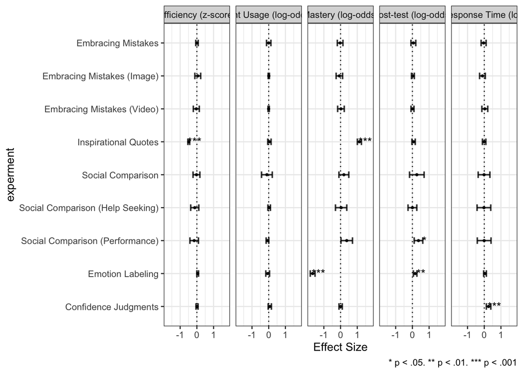

```r
coefficients<-rbind(
    RQ1_coefficients %>% mutate(experment = rownames(.), Outcome = "Response Time (log)") %>% dplyr::select(experment, Outcome, "Estimate", SE =  "Std. Error" , p ="Pr(>|t|)"),
    RQ2_coefficients %>% mutate(experment = rownames(.),Outcome = "Hint Usage (log-odds)") %>% dplyr::select(experment, Outcome, "Estimate", SE =  "Std. Error" , p ="Pr(>|z|)"),
    RQ3_coefficients %>% mutate(experment = rownames(.),Outcome = "Mastery (log-odds)") %>% dplyr::select(experment, Outcome, "Estimate", SE =  "Std. Error" , p ="Pr(>|z|)"),
    RQ4_1_coefficients %>% mutate(experment = rownames(.),Outcome = "Efficiency (z-score)") %>% dplyr::select(experment, Outcome, "Estimate", SE =  "Std. Error" , p ="Pr(>|t|)"),
        RQ4_2_coefficients %>% mutate(experment = rownames(.),Outcome = "Post-test (log-odds)") %>% dplyr::select(experment, Outcome, "Estimate", SE =  "Std. Error" , p ="Pr(>|z|)")
) %>%
  group_by(
    experment
  ) %>%
  mutate(
    p = format(round(p, 4), nsmall = 2),
    p_holm = format(round(p.adjust(p,method = "holm"), 4), nsmall = 2),
    sig_holm = ifelse(p_holm > .05, 1, 0),
    p_dots = ifelse(p_holm > .05,  "",
                    ifelse(p_holm > .01, "*",
                           ifelse(p_holm > .001, "**", "***")))
    # p_BH = format(round(p.adjust(p,method = "BH"), 4), nsmall = 2),
    # sig_BH = ifelse(p_BH > .05, 1, 0),
  ) %>%
  dplyr::rename(
    "Effect Size" = Estimate
  )
# table(coefficients$Outcome)
# coefficients$Outcome <- factor(coefficients$Outcome, levels =c("Response Time (log)", "Hint Usage (log-odds)", "Mastery (log-odds)", "Efficiency (z-score)", "Post-test (log-odds)"))
# levels(as.factor(chartr( ".", " ", coefficients$experment)))
# table(is.na(levels(as.factor(chartr( ".", " ", coefficients$experment)))))

coefficients$experment <- factor(chartr( ".", " ", coefficients$experment),
                                 levels = c(
                                   "Embracing Mistakes",
                                   "Embracing Mistakes (Image)",
                                   "Embracing Mistakes (Video)",
                                   "Inspirational Quotes",
                                   "Social Comparison",
                                   "Social Comparison (Help Seeking)",
                                   "Social Comparison (Performance)",
                                   "Emotion Labeling",
                                   "Confidence Judgments"
                                 ))

fig_1<-ggplot(coefficients,
       aes(
           x = `Effect Size`,
           y = experment,
           xmin = `Effect Size`-(SE*1.96),
           xmax = `Effect Size`+(SE*1.96),
           label = p_dots
       )) +
    geom_point(alpha = .8, size = .8) +
    geom_errorbarh(height=.2, size = .7, alpha = .8) +
    facet_grid(cols = vars(Outcome)) +
    scale_y_discrete(limits = rev(levels(coefficients$experment))) +
    geom_vline(xintercept = 0,  linetype="dotted") +
    geom_text(nudge_x = .35, size = 4) +
    coord_cartesian(xlim = c(-1.8, 1.8)) +
    theme_bw() +
    labs(
        caption = "* p < .05. ** p < .01. *** p < .001"
    )
# +
#     theme(axis.title.y = element_blank(),
#           axis.text.y = element_text(size=15),
#           axis.text.x = element_text(size=12),
#           strip.text.x = element_text(size = 15),
#           axis.title.x = element_text(size = 14),
#           plot.caption = element_text(size = 12))




fig_1
```